# Project_Draft

2025-04-08

# Group Members

- Elizabeth Huevler
- Ben Schweitzer
- Manasi Ambedkar
- Sanchith Devarajan

# Introduction

> Water is a fundamental resource that supports life, food production, and industrial development. However, the way in which water is distributed across those sectors can vary significantly between countries due to differences in economic structure, climate, and national priorities

> In this project, we will explore the question: “**Are there differences in the average proportions of total water allocated to agriculture, industry, and households between the USA and Spain over the years 2000-2024?**”

> The analysis suggests no statistical difference in the average proportions of water allocated to the three categories of aggricultural, industrial, and household use between the USA and Spain between the years of 2000 and 2024.

# Background

## Data Source

> Raw data: The dataset used in this analysis is from Kaggle, titled *“Global Water Consumption Dataset (2000-2024)”*. While the dataset is synthetic, it was generated based on real-world patterns observed in historical water use reports, climate data, and global sector usage models. It reflects realistic trends in national water consumption.

> Link: https://www.kaggle.com/datasets/atharvasoundankar/global-water-consumption-dataset-2000-2024

> For the purposes of this project, we have specifically focused on the water usage data for the USA and Spain between the years 2000 and 2024. For each country, the dataset provides the percentage of its total freshwater usage distributed across three main sectors: agricultural, industrial, and household for each year.

## Variables:

- Country: Country name (filtered to either USA or Spain)
- Year: Number between 2000 - 2024 indictating the year of the data
- Agricultural Use: Proportion of total water used in the agricultural sector
- Industrial Use: Proportion of total water used in the industry sector
- Household Use: Proportion of total water used in the household sector

## Data Structure

> Each row in the dataset corresponds to a specific country (USA or Spain) and year, showing the distribution of its total freshwater usage as percentages across the agricultural, industrial, and household sectors for that year.

> Our sample includes data for the USA and Spain over the 25-year period (2000-2024), resulting in 25 rows for each country (50 rows in total). To compare the overall water allocation of the two countries, we will calculate the average percentage of water used in each sector across these years for both the USA and Spain.

## Data Cleaning and Processing:

> The initial dataset was filtered to retain only the data for Spain and the USA for all available years. The dataset was complete for the relevant countries and years, so no imputation was necessary. The processing involved calculating the average percentage of water used in the agricultural, industrial, and household sectors for each country across the years 2000-2024.

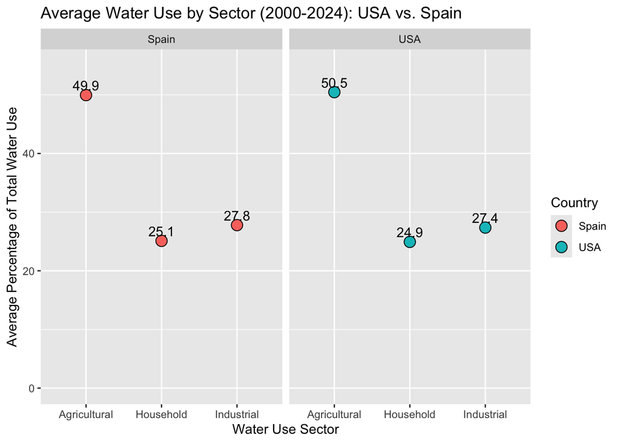

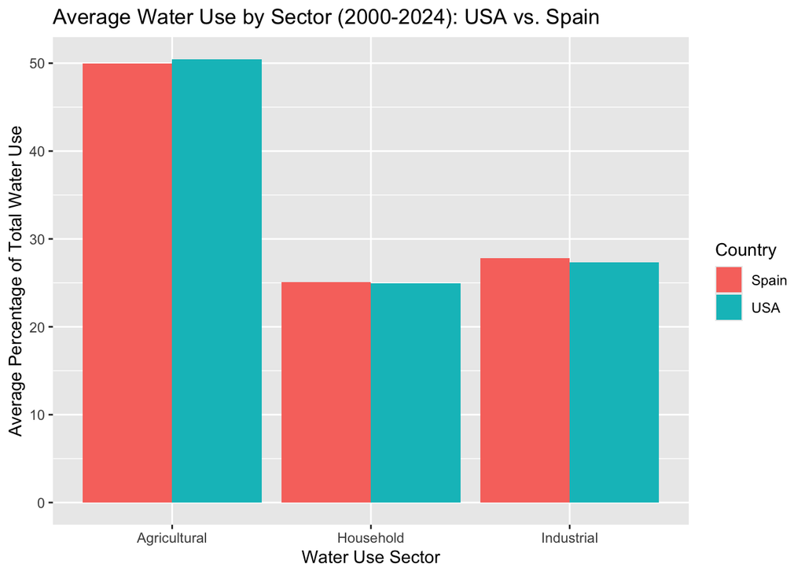

> These graphs provide a summary view of the typical water allocation in each country over a specific period. The graphs visually support our thesis by showing that the average proportion of water usage across sectors is similar between the USA and Spain.

# Statistical Analysis

## Parameter of Intrest

> Our parameters of interest are the true differences in the average proportions of total water use allocated to each sector between the USA and Spain over the period 2000-2024. Let:
- $X_A \sim N(\mu_{A,USA}, \sigma_{A,USA}^2)$: Agricultural water use in the USA
- $Y_A \sim N(\mu_{A,Spain}, \sigma_{A,Spain}^2)$: Agricultural water use in Spain
- $X_I \sim N(\mu_{I,USA}, \sigma_{I,USA}^2)$: Industrial water use in the USA
- $Y_I \sim N(\mu_{I,Spain}, \sigma_{I,Spain}^2)$: Industrial water use in Spain
- $X_H \sim N(\mu_{H,USA}, \sigma_{H,USA}^2)$: Household water use in the USA
- $Y_H \sim N(\mu_{H,Spain}, \sigma_{H,Spain}^2)$: Household water use in Spain

Our parameter of interest in each case is the difference in means $\mu_{USA} - \mu_{Spain}$ for each sector.

## Type of Inference

> We use a difference in two means as our method of inference. This is appropriate for comparing the means of yearly percentages between the two countries for each sector.

## Assumptions

- Independence: Water use proportions for each year were assumed to be independent across time, as each year’s distribution reflects separate policy and environmental conditions.
- Normality: It is assumed that the sample proportions for each group are approximately normally distributed based on the Central Limit Theorem, which approximates normality for the means of sample sizes being near or above 30.
- Constant Variance: As a part of being normally distributed, we can assume that the variance of the sample proportions are approximately constant

## Hypothesis

> For each category (agriculture, industry, household), we conduct two-sided hypothesis tests:
- Agriculture:
- $H_0: \mu_{A,USA} = \mu_{A,Spain}$ : The average proportion of water used for agriculture is the same in the USA and Spain.
- $H_A: \mu_{A,USA} \neq \mu_{A,Spain}$ : The average proportion of water used for agriculture is different in the USA and Spain.
- Industry:
- $H_0: \mu_{I,USA} = \mu_{I,Spain}$ : The average proportion of water used for industry is the same in the USA and Spain.
- $H_A: \mu_{I,USA} \neq \mu_{I,Spain}$ : The average proportion of water used for industry is different in the USA and Spain.
- Household:
- $H_0: \mu_{H,USA} = \mu_{H,Spain}$ : The average proportion of water used for household use is the same in the USA and Spain.
- $H_A: \mu_{H,USA} \neq \mu_{H,Spain}$ : The average proportion of water used for household use is different in the USA and Spain.

## Test Statistic and Null Distribution

> The test statistic is calculated as:

$$t = \frac{\bar{x} -
\bar{y}}{\sqrt{\frac{s_x^2}{n_x} + \frac{s_y^2}{n_y}}}$$

> where:
- $\bar{x}, \bar{y}$: Sample means for USA and Spain.
- $s_x^2, s_y^2$: Sample variances for USA and Spain.
- $n_x, n_y$: Sample sizes for USA and Spain.
- The degrees of freedom: 48 (25 years + 25 years - 2)

> We repeat this process 3 times for the three different sectors we are testing

## Results

### Agricultural Water Use:

> The statistical analysis yielded a test statistic of -0.368 with 48 degrees of freedom. The corresponding p-value was 0.714, which means there is a high probability that the observed difference in agricultural water use between the USA and Spain is due to random variation, not a real difference.

## Interpretation: Compare p-value with alpha (alpha = 0.05)

> For each sector, we compared the p-value to our chosen significance level (alpha = 0.05). If the p-value is less than 0.05, we would reject the null hypothesis and conclude that there is a statistically significant difference in the average proportion of water used in that sector between the USA and Spain during the period 2000-2024.

> In our analysis:
- For agricultural water use, the p-value is 0.714, which is greater than 0.05.
- For industrial water use, the p-value is 0.719, which is greater than 0.05.
- For household water use, the p-value is 0.843, which is greater than 0.05.

> Therefore, for all three sectors, we fail to reject the null hypothesis. This suggests that based on our data and analysis, there is no statistically significant difference in the average proportion of water allocated to agriculture, industry, or households between the USA and Spain during the period 2000-2024.

## Confidence Interval

### Agricultural Water Use:

> The 95% confidence interval for the difference in mean agricultural water use between Spain and the USA ranged from -3.26 to 2.25. This means the true difference in the average proportion of agricultural water use between Spain and the USA could range from 3.26 percentage points lower in Spain to 2.25 percentage points higher in Spain.

### Industrial Water Use:

> The 95% confidence interval for the difference in mean industrial water use between Spain and the USA ranged from -1.93 to 2.77. This means the true difference in the average proportion of industrial water use between Spain and the USA could range from 1.93 percentage points lower in Spain to 2.77 percentage points higher in Spain.

### Household Water Use:

> The 95% confidence interval for the difference in mean household water use between Spain and the USA ranged from -1.58 to 1.92. This means the true difference in the average proportion of household water use between Spain and the USA could range from 1.58 percentage points lower in Spain to 1.92 percentage points higher in Spain.

## Interpretation:

> Since all three confidence intervals include zero, it means that the possibility exists that there is no difference at all between the two countries’ water use across these sectors. This further supports our conclusion that there is no statistically significant difference in the average water allocation to these sectors between the USA and Spain during the studied period. If a confidence interval contains zero, it means that a difference of zero is a plausible value for the true difference in population means.

# Discussion

> For non-statistical readers, a confidence interval is a way of estimating a value that is a range we believe the true value lies within. The confidence level is how confident we are that the value is inside of this range. In our instance, we are 95% sure that the real difference in allocations is within the ranges mentioned above. Since all of these ranges include 0, it is reasonable to think the real value is or is close to 0.

## Shortcomings

> For starters, the data we used in this experiment was synthetic, meaning it was built based on patterns instead of exact, measured and observed values. While there is reason to believe this data is mostly accurate, it may not be as accurate as a dataset that is made up of observed values.

> The analysis is only limited to 25 years. Perhaps if we had a longer span of time to analyze, we would get differing or more insightful results.

## Going Forward

> We believe if we were able to find a more in-depth dataset that addresed these shortcomings, we might be able to make more precise predictions about the allocations of water among these two countries

> For future research, we would recommend potentially working with different or more countries in order to see if there are notable differences in water allocation between different pairs of countries. Perhaps countries with much different climates, social norms, or health conditions would allocate their water significantly differently from each other.